# Capstone Project

## Visual aids

I ran some plots to see how the mean age has changed over time. This plot shows the mean age has slightly decreased for overall athlete events.

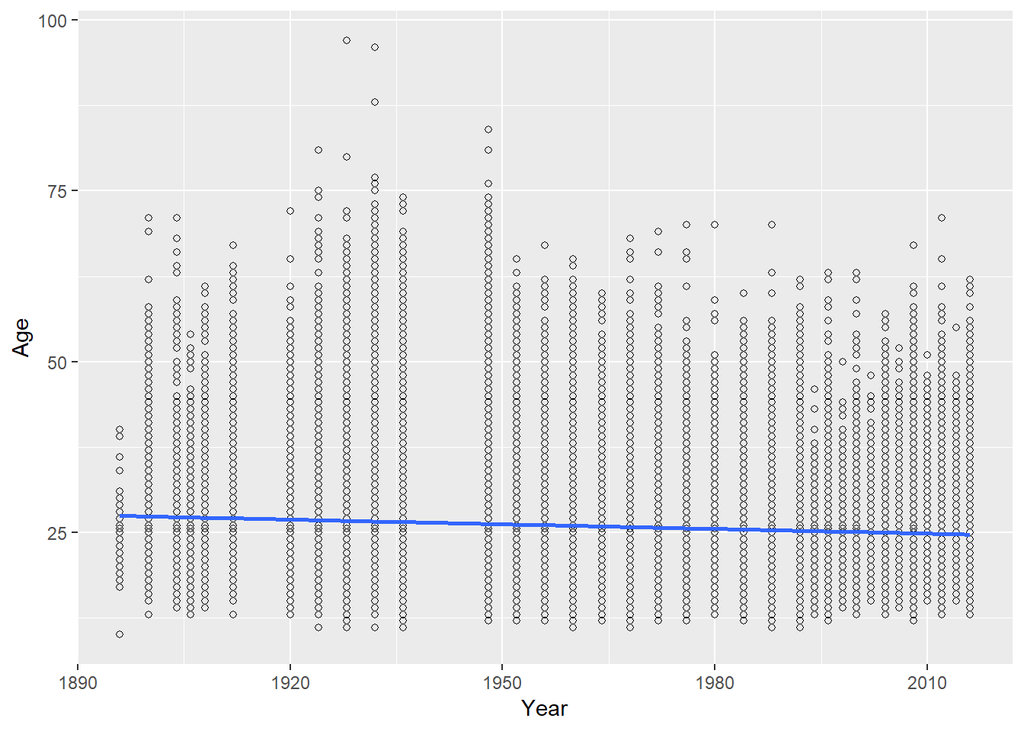

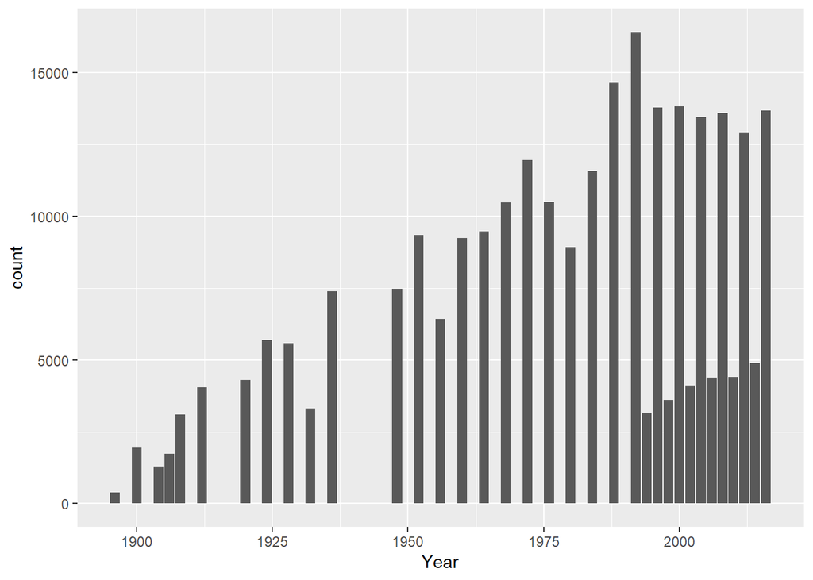

```r
ggplot(Athlete_event_whole, aes(x = Year, fill = Age_over_30)) +
  geom_bar(position = "dodge")
```

Then I started to think what possible articles have already been written on this topic. So I went to Google and found 3 articles that help to provide more direction.

The first article discusses Elite Athletes over 40 for the Pyeongchange Winter Olympics: https://www.bloomberg.com/news/articles/2018-02-14/wisdom-and-drive-older-olympians-becoming-the-norm . The second article discusses is 30 the new 20 for Olympic Athletes: https://venngage.com/blog/olympics/ . Both of these articles discuss athletes that were successful and the latter article does analysis comparing Gymnastics to Track & Field. This analysis combined with the third article I read https://www.verywellfit.com/olympic-sports-youre-not-too-old-for-4075439 which discusses 10 Summer Olmpic Sports Your not too old to quality for. As the 2020 Summer Olympic games are upcoming and the dataset data runs through 2016 Summer Olmpics, I thought I will select 2 of the sports on the list and compare if the average age is actually increasing. Or if they have always been sports that have above typical Olympic athlete mean age. I chose:

## Rowing

[figure not shown]

## Equestrianism

[figure not shown]

Both sports have a long history in the Olmpics and moderate participation.

Let’s start by looking at the proportion of particpants for Equestrianism. Considering participation over the years, the top 3 are in the year 2000+. And as I look at those over 30 earning medals, the result in 2016 was 9.9% compared to 2008 in which it was 12.1% and 12.5% in 2000 which shows while particpation of those over 30 has increased in Equestrianism, it has not reflected in earning a medal, however it is vastly higher than the results in overall events of 2.5% so participatin in Equestrianism does suggest a higher opportunity to win a medal for those participants over 30 years old.

```r
Train_Equ %>%
  group_by(Year) %>%
  summarise(
    participants = n(),
    over_30      = sum(Age > 30)
  ) %>%
  mutate(
    percent_over_30 = over_30/participants*100
  ) %>%
  arrange(desc(percent_over_30))
```

```
## # A tibble: 25 x 4
##     Year participants over_30 percent_over_30
##    <int>        <int>   <int>           <dbl>
##  1  2012          350     266            76
##  2  2016          355     265            74.6
##  3  2008          340     253            74.4
##  4  1932           65      48            73.8
##  5  2000          295     217            73.6
##  6  1928          232     168            72.4
##  7  1948          207     145            70.0
##  8  1936          256     179            69.9
##  9  1996          343     239            69.7
## 10  2004          371     242            65.2
## # ... with 15 more rows
```

# Equestrian review of over 30 earning medal over the years

```r
Train_Equ %>%
  group_by(Year,Medal_value) %>%
  summarise(
    participants = n(),
    over_30      = sum(Age > 30)
   ) %>%
  mutate(
      percent_over_30 = over_30/participants*100
  ) %>%
  arrange(desc(Year))
```

```
## # A tibble: 50 x 5
## # Groups:   Year [25]
##     Year Medal_value participants over_30 percent_over_30
##    <int>       <dbl>        <int>   <int>           <dbl>
##  1  2016           0          310     230            74.2
##  2  2016           1           45      35            77.8
##  3  2012           0          305     238            78.0
##  4  2012           1           45      28            62.2
##  5  2008           0          295     212            71.9
##  6  2008           1           45      41            91.1
##  7  2004           0          324     205            63.3
##  8  2004           1           47      37            78.7
##  9  2000           0          250     180            72
## 10  2000           1           45      37            82.2
## # ... with 40 more rows
```

```r
mean(Athlete_event_whole)
```

```
## [1] NA
```

```r
mean(Train_Equ)
```

```
## [1] NA
```

```r
mean(Test_Row)
```

```
## [1] NA
```

```r
tapply(Athlete_event_whole$Age, Athlete_event_whole$Year, meanfun)
```

```
## $`1896`
##      min      max     mean
## 10.00000 40.00000 24.42835
##
## $`1900`
##      min      max     mean
## 13.00000 71.00000 27.61516
##
## $`1904`
##      min      max     mean
## 14.00000 71.00000 26.45779
##
## $`1906`
##      min      max     mean
## 13.00000 54.00000 26.45284
##
## $`1908`
##      min      max     mean
## 14.00000 61.00000 26.67444
##
## $`1912`
##     min     max    mean
## 13.0000 67.0000 27.4621
##
## $`1920`
##      min      max     mean
## 13.00000 72.00000 28.55582
##
## $`1924`
##      min      max     mean
## 11.00000 81.00000 27.80836
##
## $`1928`
##      min      max     mean
## 11.00000 97.00000 28.49826
##
## $`1932`
##    min    max   mean
## 11.000 96.000 31.884
##
```

[output cut: 84 more lines]

```
## $`2010`
##      min      max     mean
## 15.00000 51.00000 26.12426
##
## $`2012`
##      min      max     mean
## 13.00000 71.00000 25.96138
##
## $`2014`
##      min      max     mean
## 15.00000 55.00000 25.98732
##
## $`2016`
##      min      max     mean
## 13.00000 62.00000 26.20792
```

```r
tapply(Train_Equ$Age, Train_Equ$Year, meanfun)
```

```
## $`1900`
##      min      max     mean
## 20.00000 69.00000 32.79808
##
## $`1912`
##      min      max     mean
## 19.00000 51.00000 32.18759
##
## $`1920`
##      min      max     mean
## 21.00000 59.00000 30.72746
##
## $`1924`
##     min     max    mean
## 21.0000 59.0000 31.8678
##
## $`1928`
##      min      max     mean
## 24.00000 63.00000 35.86648
##
## $`1932`
##      min      max     mean
## 25.55690 49.00000 36.02064
##
## $`1936`
##      min      max     mean
## 22.00000 72.00000 35.48047
##
## $`1948`
##      min      max     mean
## 23.00000 55.00000 35.58796
##
## $`1952`
##      min      max     mean
## 18.00000 63.00000 34.07445
##
## $`1956`
##     min     max    mean
## 19.0000 67.0000 33.2526
##
```

[output cut: 44 more lines]

```
## $`2004`
##      min      max     mean
## 18.00000 57.00000 35.15633
##
## $`2008`
##      min      max     mean
## 16.00000 67.00000 36.90588
##
## $`2012`
##   min   max  mean
## 18.00 71.00 37.82
##
## $`2016`
##      min      max     mean
## 18.00000 62.00000 37.63099
```

```r
tapply(Test_Row$Age, Test_Row$Year, meanfun)
```

```
## $`1900`
##      min      max     mean
## 15.00000 36.00000 24.38715
##
## $`1904`
##      min      max     mean
## 16.00000 40.00000 26.81177
##
## $`1906`
##      min      max     mean
## 14.00000 40.00000 25.34489
##
## $`1908`
##      min      max     mean
## 18.00000 44.00000 24.48421
##
## $`1912`
##      min      max     mean
## 16.00000 43.00000 25.06882
##
## $`1920`
##      min      max     mean
## 15.00000 58.00000 26.20331
##
## $`1924`
##      min      max     mean
## 14.00000 41.00000 25.11429
##
## $`1928`
##      min      max     mean
## 13.00000 42.00000 24.35621
##
## $`1932`
##      min      max     mean
## 16.00000 41.00000 24.98344
##
## $`1936`
##      min      max     mean
## 12.00000 45.00000 24.81227
##
```

[output cut: 56 more lines]

```
## $`2004`
##      min      max     mean
## 17.00000 40.00000 26.15385
##
## $`2008`
##      min      max     mean
## 19.00000 48.00000 26.71403
##
## $`2012`
##   min   max  mean
## 17.00 52.00 27.12
##
## $`2016`
##      min      max     mean
## 18.00000 56.00000 26.86727
```

Now the question is if the mean age is higher will that translate to having more athletes over 30 and is it increasing. And this plot shows the age trend for both Rowing and Equestrian combined

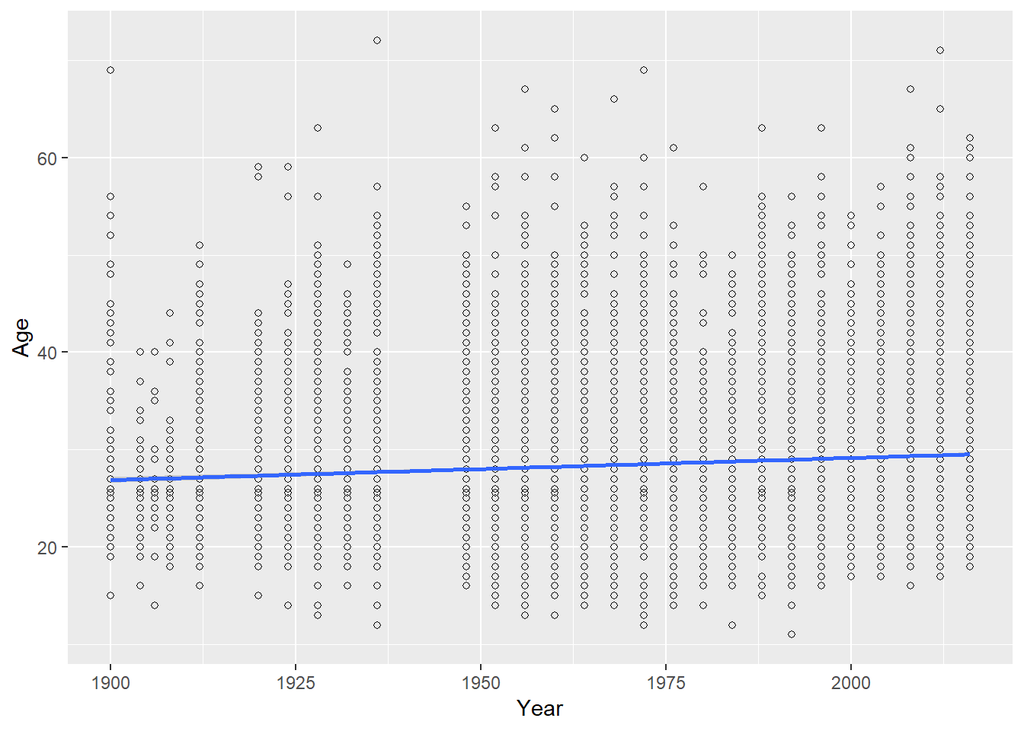

```r
ggplot(Compare_Row_Equest_all, aes(x=Year, y=Age)) +
  geom_point(shape=1) +
  geom_smooth(method=lm)
```

## Next Steps

Ultimately I would like to know if I am looking to earn a medal and over age 30 which sport should I choose. I am now going to compare these two sports, each of which have a higher mean age and discover if this mean has increased over the years. I need to run analysis on each sport and if the mean age has changed. And does the higher mean age increase or decrease the probablity of those athletes over 30 earning a medal.

This trend would not only provide more opportunities to older athletes, but also to those companies that market to athletes on the different needs. This would open a growth segement in their marketing to these athletes.

## My findings

After cleaning the data and running plots which I reflected above, as mentioned I have focused on the Sports Equestrian and Rowing. I will create my training set using the Equestrian data and then validate using the Rowing data. This plot shows in looking at Equestrian only, the age is increasing over time:

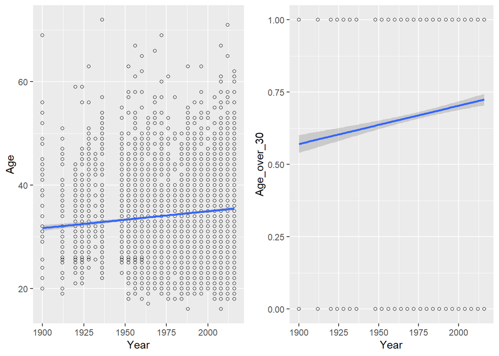

```r
p1<-ggplot(Train_Equ, aes(x=Year, y=Age)) +
  geom_point(shape=1) +    # Use hollow circles
  geom_smooth(method=lm)    # Add linear regression line

#Line plot over time Train set
p2<-ggplot(Train_Equ, aes(x=Year, y= Age_over_30)) +
  geom_point(shape=1) +    # Use hollow circles
  geom_smooth(method=lm)    # Add linear regression line

grid.arrange(p1, p2, ncol = 2)
```

I also ran a few other plots to evaluate Medals and consider Age over 30 and NOC.

[figure not shown]

```r
# medal over 30 Train set
p1<-ggplot(Train_Equ, aes(Team, Age)) +
  geom_point() +
  facet_grid(Medal ~.)
#mean age train
p2<-ggplot(Train_Equ, aes(Year, mean(Age))) +
  geom_point() +
  facet_grid(Medal ~.)
#bar plot on train set
p3<-ggplot(Train_Equ, aes (x = Year, fill= factor(Age_over_30))) +
  geom_histogram(binwidth = 1) +
  facet_grid(Medal_value ~ .)
#line chart to review mean age
p4<-ggplot(Train_Equ, aes(Year, Age, group=mean(Age))) +
  geom_line(color = "blue") +
  geom_point()
#plot to add color on over 30
p5<-ggplot(Train_Equ, aes(x=Sport, y=Team, color >= 30(Age))) +
  geom_point(shape=19,      # Use solid circles
             alpha=1/4, aes(color = Age))     # 1/4 opacity

#plot team and Age and reflect on if earned a medal
p6<-ggplot(Train_Equ, aes(x=Team, y=Age)) +
  geom_point(aes(color = Medal_value))

#plot to compare sex vs age
p7<-ggplot(Train_Equ, aes(x=Sex, y=Age)) +
  geom_point(aes(color = Medal_value))

grid.arrange(p1, p2, p3, p4, p5, p6, p7, ncol = 3)
```

Then starting to review linear regressions on my train set I found R squared in the under 1%, which scared me as that is quite low.

```r
e.age.out <- lm(Age >30 ~Medal_value,
              data=Train_Equ)
summary(e.age.out)
```

```
##
## Call:
## lm(formula = Age > 30 ~ Medal_value, data = Train_Equ)
##
## Residuals:
##     Min      1Q  Median      3Q     Max
## -0.6829 -0.6036  0.3964  0.3964  0.3964
##
## Coefficients:
##             Estimate Std. Error t value Pr(>|t|)
## (Intercept) 0.603644   0.006622  91.157  < 2e-16 ***
## Medal_value 0.079258   0.016979   4.668  3.1e-06 ***
## ---
## Signif. codes:  0 '***' 0.001 '**' 0.01 '*' 0.05 '.' 0.1 ' ' 1
##
## Residual standard error: 0.4857 on 6342 degrees of freedom
## Multiple R-squared:  0.003424,   Adjusted R-squared:  0.003267
## F-statistic: 21.79 on 1 and 6342 DF,  p-value: 3.104e-06
```

I made some modifications by adding NOC and Age was able to raise it to 54%. This is still much lower than I wish, but currently it is the best result I can achieve.

```r
age.out9 <- lm(Age_over_30 ~ Medal_value + NOC + Age,
                 data=Train_Equ)
summary(age.out9)
```

```
##
## Call:
## lm(formula = Age_over_30 ~ Medal_value + NOC + Age, data = Train_Equ)
##
## Residuals:
##      Min       1Q   Median       3Q      Max
## -1.13278 -0.29131 -0.00316  0.29462  0.67961
##
## Coefficients:
##               Estimate Std. Error t value Pr(>|t|)
## (Intercept) -1.1284387  0.2289323  -4.929 8.47e-07 ***
## Medal_value  0.0209401  0.0120189   1.742   0.0815 .
## NOCARG       0.4810593  0.2291191   2.100   0.0358 *
## NOCAUS       0.4348595  0.2285880   1.902   0.0572 .
## NOCAUT       0.3697540  0.2296910   1.610   0.1075
## NOCAZE       0.2449358  0.3220121   0.761   0.4469
## NOCBEL       0.3567321  0.2287614   1.559   0.1190
## NOCBER       0.4212939  0.2474417   1.703   0.0887 .
## NOCBLR       0.4564647  0.2628048   1.737   0.0825 .
## NOCBOL       0.2971546  0.2938628   1.011   0.3120
## NOCBRA       0.4382859  0.2290212   1.914   0.0557 .
## NOCBUL       0.4689073  0.2306512   2.033   0.0421 *
## NOCCAM       0.0240601  0.3218951   0.075   0.9404
## NOCCAN       0.3756046  0.2285015   1.644   0.1003
## NOCCHI       0.5391514  0.2320274   2.324   0.0202 *
## NOCCHN       0.3559406  0.2474541   1.438   0.1504
## NOCCOL       0.4220815  0.2393085   1.764   0.0778 .
## NOCCRO       0.5220699  0.3217140   1.623   0.1047
## NOCCZE       0.8031844  0.3218010   2.496   0.0126 *
## NOCDEN       0.5008998  0.2292437   2.185   0.0289 *
## NOCDOM       0.2007961  0.3939473   0.510   0.6103
## NOCECU       0.4029190  0.2937639   1.372   0.1702
## NOCEGY       0.4577419  0.2393547   1.912   0.0559 .
## NOCESP       0.4611822  0.2287254   2.016   0.0438 *
## NOCEUN       0.3769423  0.2423865   1.555   0.1200
## NOCFIN       0.4055976  0.2315577   1.752   0.0799 .
## NOCFRA       0.4229171  0.2280981   1.854   0.0638 .
## NOCFRG       0.4116670  0.2298411   1.791   0.0733 .
## NOCGBR       0.3852649  0.2282212   1.688   0.0914 .
## NOCGDR       0.4864851  0.2356909   2.064   0.0391 *
```

[output cut: 39 more lines]

```
## NOCUAR       0.5025554  0.2628262   1.912   0.0559 .
## NOCUKR       0.5870956  0.2361513   2.486   0.0129 *
## NOCURS       0.3781259  0.2291089   1.650   0.0989 .
## NOCURU       0.2038921  0.2517333   0.810   0.4180
## NOCUSA       0.4669012  0.2281430   2.047   0.0407 *
## NOCVEN       0.4794869  0.2493824   1.923   0.0546 .
## NOCYUG       0.5232072  0.2580845   2.027   0.0427 *
## NOCZIM      -0.0361787  0.3941167  -0.092   0.9269
## Age          0.0401592  0.0004922  81.592  < 2e-16 ***
## ---
## Signif. codes:  0 '***' 0.001 '**' 0.01 '*' 0.05 '.' 0.1 ' ' 1
##
## Residual standard error: 0.3217 on 6266 degrees of freedom
## Multiple R-squared:  0.5382, Adjusted R-squared:  0.5325
## F-statistic: 94.84 on 77 and 6266 DF,  p-value: < 2.2e-16
```

I also reviewed under Clustering under the Training set. The majority of the athletes over 30 appear to full under the 2nd Cluster, though in looking at some of the details, I found some ages under 30 listed so the cluster is still mixed. Based on these results, I will not focus on Clustering with the Test set.

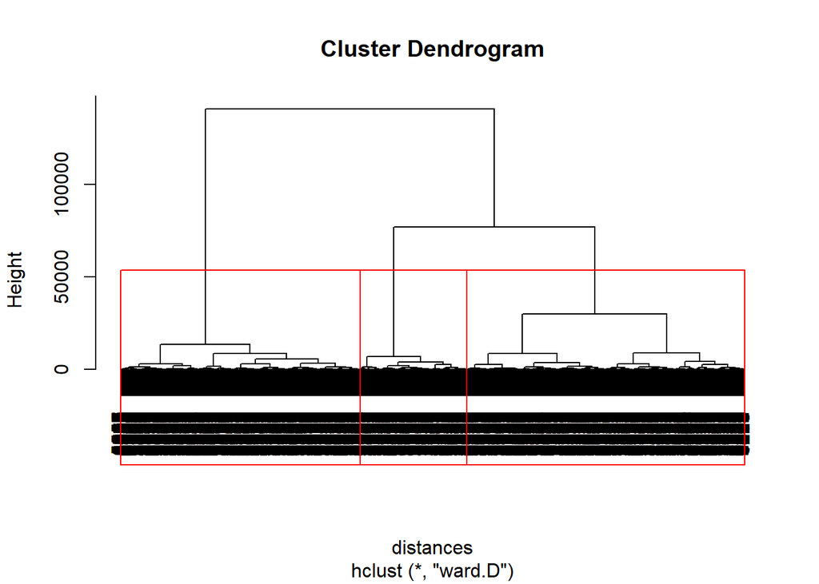

```r
plot(clusterathlete)
rect.hclust(clusterathlete, k=3, border="red")
```

##Test phase Taking this result and moving on to the test group of Rowing in which the article mentioned this is another sport with higher than average age participation and on the increase, let’s see if this case is true. We will again look at the proportion of participants in Rowing which shows the trend of increasing as the highest participation percentage has happened in the year 2000+. And as I look at those over 30 earning medals, the result in 2016 was 6.7% compared to 2008 in which it was 7.1% and 5.3% in 2000 showing since year 2000, there has been an increase in Rowing of those over 30 earning a medal. Plus it is substantially higher than the results in overall events of 2.5% so participatin in Rowing does suggest a higher opportunity to win a medal for those participants over 30 years old, though perhaps not as high as Equestrianism.

```r
#Reflecting increase over last 20 years
Test_Row %>%
  group_by(Year) %>%
  summarise(
    participants = n(),
    over_30      = sum(Age > 30)
  ) %>%
  mutate(
    percent_over_30 = over_30/participants*100
  ) %>%
  arrange(desc(percent_over_30))
```

```
## # A tibble: 28 x 4
##     Year participants over_30 percent_over_30
##    <int>        <int>   <int>           <dbl>
##  1  2012          550     110            20
##  2  2016          550     100            18.2
##  3  2000          561     101            18.0
##  4  1904           46       8            17.4
##  5  2008          563      94            16.7
##  6  2004          559      89            15.9
##  7  1912          197      30            15.2
##  8  1920          144      21            14.6
##  9  1948          318      43            13.5
## 10  1996          621      77            12.4
## # ... with 18 more rows
```

# Percentage of those over 30 earning a medal through the years

```r
Test_Row %>%
  group_by(Year,Medal_value) %>%
  summarise(
    participants = n(),
    over_30      = sum(Age > 30)
  ) %>%
  mutate(
    percent_over_30 = over_30/participants*100
  ) %>%
  arrange(desc(Year))
```

```
## # A tibble: 56 x 5
## # Groups:   Year [28]
##     Year Medal_value participants over_30 percent_over_30
##    <int>       <dbl>        <int>   <int>           <dbl>
##  1  2016           0          406      63            15.5
##  2  2016           1          144      37            25.7
##  3  2012           0          406      81            20.0
##  4  2012           1          144      29            20.1
##  5  2008           0          419      54            12.9
##  6  2008           1          144      40            27.8
##  7  2004           0          415      55            13.3
##  8  2004           1          144      34            23.6
##  9  2000           0          417      71            17.0
## 10  2000           1          144      30            20.8
## # ... with 46 more rows
```

Again these few plots show Rowing also has age of participation increasing over the years, similar to Equestrian.

[figure not shown]

```r
#plot team and Age and reflect on if earned a medal
p1<-ggplot(Test_Row, aes(x=Team, y=Age)) +
  geom_point(aes(color = Medal_value))

#plot to compare sex vs age
p2<-ggplot(Test_Row, aes(x=Sex, y=Age)) +
  geom_point(aes(color = Medal_value))

#plot over time - test set
p3<-ggplot(Test_Row, aes(x=Year, y=Age)) +
  geom_point(shape=1) +    # Use hollow circles
  geom_smooth(method=lm)    # Add linear regression line


#Line plot over time Test set
p4<-ggplot(Test_Row, aes(x=Year, y= Age_over_30)) +
  geom_point(shape=1) +    # Use hollow circles
  geom_smooth(method=lm)    # Add linear regression line

#line plot over Year, Age
p5<-ggplot(Test_Row, aes(Year, Age, group=Age_over_30)) +
  geom_line(color= "blue")+
  geom_point()

#bar chart Test set looking at year by age over 30
p6<-ggplot(Test_Row, aes(x = Year, fill = Age_over_30)) +
  geom_bar(position = "dodge")

#line chart to review mean age
p7<-ggplot(Test_Row, aes(Year, Age, group=mean(Age))) +
  geom_line(color = "blue") +
  geom_point()

#histogram on Age & medals of test set
p8<-ggplot(Test_Row, aes(Age, fill = factor(Medal))) +
  geom_histogram(binwidth = 1)

#bar plot on test set
p9<-ggplot(Test_Row, aes (x = Year, fill= factor(Age_over_30))) +
  geom_histogram(binwidth = 1) +
  facet_grid(Medal_value ~ .)

#plot to add color on over 30
p10<-ggplot(Test_Row, aes(x=Sport, y=Team, color >= 30(Age))) +
  geom_point(shape=19,      # Use solid circles
             alpha=1/4, aes(color = Age))     # 1/4 opacity

grid.arrange(p1, p2, p3, p4, p5, p6, p7, p8, p9, p10, ncol = 3)
```

Then following with linear regression result which similar to the train set has 51% r squared.

```r
age.out21 <- lm(Age_over_30 ~ Medal_value + NOC + Age,
               data=Test_Row)
summary(age.out21)
```

```
##
## Call:
## lm(formula = Age_over_30 ~ Medal_value + NOC + Age, data = Test_Row)
##
## Residuals:
##      Min       1Q   Median       3Q      Max
## -1.19770 -0.17530 -0.04576  0.11682  0.68153
##
## Coefficients:
##               Estimate Std. Error t value Pr(>|t|)
## (Intercept) -1.3609854  0.0788204 -17.267   <2e-16 ***
## Medal_value  0.0043422  0.0057601   0.754    0.451
## NOCANG      -0.1938786  0.1899661  -1.021    0.307
## NOCANZ      -0.0645415  0.1096775  -0.588    0.556
## NOCARG       0.0382350  0.0796322   0.480    0.631
## NOCAUS       0.0331474  0.0783292   0.423    0.672
## NOCAUT       0.0428239  0.0804375   0.532    0.594
## NOCAZE      -0.0178562  0.1450895  -0.123    0.902
## NOCBAH       0.0701549  0.2572176   0.273    0.785
## NOCBEL       0.0198493  0.0796837   0.249    0.803
## NOCBER       0.0114808  0.1899670   0.060    0.952
## NOCBLR       0.0572447  0.0832386   0.688    0.492
## NOCBOH      -0.0471933  0.2572129  -0.183    0.854
## NOCBRA       0.0023592  0.0803382   0.029    0.977
## NOCBUL       0.0532693  0.0797341   0.668    0.504
## NOCCAN       0.0097375  0.0782722   0.124    0.901
## NOCCHI       0.0634532  0.0891904   0.711    0.477
## NOCCHN       0.0229396  0.0798106   0.287    0.774
## NOCCMR      -0.1645415  0.1899650  -0.866    0.386
## NOCCOL       0.1288290  0.2572219   0.501    0.616
## NOCCRO      -0.0128464  0.0855981  -0.150    0.881
## NOCCUB       0.0352024  0.0804591   0.438    0.662
## NOCCZE       0.0322927  0.0838737   0.385    0.700
## NOCDEN       0.0404049  0.0789320   0.512    0.609
## NOCECU      -0.0471933  0.2572129  -0.183    0.854
## NOCEGY      -0.0479096  0.0849634  -0.564    0.573
## NOCESA       0.1092710  0.1614509   0.677    0.499
## NOCESP       0.0586074  0.0803745   0.729    0.466
## NOCEST       0.0666860  0.0876748   0.761    0.447
## NOCEUN       0.0508708  0.0854122   0.596    0.551
```

[output cut: 64 more lines]

```
## NOCURU       0.0230271  0.0859181   0.268    0.789
## NOCUSA       0.0191707  0.0780632   0.246    0.806
## NOCUZB       0.1092710  0.1266587   0.863    0.388
## NOCVAN      -0.0471933  0.2572129  -0.183    0.854
## NOCVEN      -0.0178562  0.1899656  -0.094    0.925
## NOCVIE       0.0603759  0.1266521   0.477    0.634
## NOCYUG       0.0444193  0.0804402   0.552    0.581
## NOCZIM       0.0876447  0.1208605   0.725    0.468
## Age          0.0586741  0.0005655 103.756   <2e-16 ***
## ---
## Signif. codes:  0 '***' 0.001 '**' 0.01 '*' 0.05 '.' 0.1 ' ' 1
##
## Residual standard error: 0.2452 on 10492 degrees of freedom
## Multiple R-squared:  0.5195, Adjusted R-squared:  0.5148
## F-statistic: 111.2 on 102 and 10492 DF,  p-value: < 2.2e-16
```

I hope these results can show Sports companies that focusing on all age groups is important. This research and predicting trends could continue focusing on NOC for which country teams have the highest chance of earning a medal over 30 to further focus your marketing. It could also be analysized for Sex, especially focusing on Sport to determine which market segment to focus product creation and market needs. While the percentage of athletes earning a medal or even participating in an Olympic event over the age of 30 will always be in the minority, highlighting these achievements in your marketing can modivate your target market to aspire to be like them and the products used to get them there.